# Models

Eudald Correig

11/6/2020

# Model bàsic

Regressió logística bàsica

```
##
## Call:
## glm(formula = Mort ~ ., family = "binomial", data = df[, c(1:46,
##     62)])
##
## Deviance Residuals:
##      Min        1Q    Median        3Q       Max
## -2.68580  -0.54158  -0.25175  -0.05854   2.91197
##
## Coefficients:
##                                       Estimate Std. Error z value Pr(>|z|)
## (Intercept)                         -3.862e+00  1.829e+00  -2.112 0.034669
## Edat                                 8.976e-02  1.178e-02   7.618 2.58e-14
## SexeHome                            -1.972e-01  2.416e-01  -0.816 0.414345
## TabacNo                             -2.225e-01  2.485e-01  -0.896 0.370509
## TabacSí                             -1.160e-02  4.414e-01  -0.026 0.979042
## HTASí                                5.037e-01  2.765e-01   1.822 0.068486
## HiperlipemiaSí                       4.502e-01  2.512e-01   1.792 0.073159
## DiabetesSí                          -9.552e-02  3.305e-01  -0.289 0.772549
## ObesitatSí                          -1.765e-01  2.230e-01  -0.791 0.428662
## Ant.CISí                            -1.031e-01  2.688e-01  -0.383 0.701351
## Ant.IctusSí                          4.112e-02  2.912e-01   0.141 0.887731
## Ant.MVPSí                            5.385e-01  3.003e-01   1.793 0.072912
## Ant.Ins.CardSí                       5.445e-01  2.717e-01   2.004 0.045026
## Ant.MPOC.AsmaSí                     -2.506e-02  2.271e-01  -0.110 0.912152
## Ant.MHepCSí                          3.726e-01  5.607e-01   0.665 0.506325
## Ant.MRCSí                            2.639e-01  2.458e-01   1.073 0.283110
## Ant.MReuSí                           2.532e-01  4.123e-01   0.614 0.539161
## CàncerSí                             5.526e-01  2.505e-01   2.206 0.027356
## EstatinesSí                         -4.959e-01  2.429e-01  -2.041 0.041204
## EzetimibaSí                         -6.854e-01  5.516e-01  -1.243 0.214014
## FibratSí                             1.168e+00  4.802e-01   2.432 0.015021
## ResinesSí                           -1.079e+01  1.455e+03  -0.007 0.994083
## Omacor..1gSí                         1.734e+01  6.236e+02   0.028 0.977820
## IECASí                              -6.133e-01  2.374e-01  -2.584 0.009778
## ARA2Sí                              -9.032e-01  2.932e-01  -3.081 0.002063
## InsulinaSí                           7.602e-01  3.183e-01   2.388 0.016921
## ISGLT2Sí                            -1.270e+00  7.086e-01  -1.793 0.072979
## GLP1Sí                              -2.179e-02  5.398e-01  -0.040 0.967794
## Altres.trac..DMSí                    3.613e-01  3.158e-01   1.144 0.252622
```

[output cut: 69 more lines]

```
## Ins.RespSí
## Sa.O2                               ***
## PaO2..mmHg.                         .
## FIO2..decimals.
## PaFi                                ***
## ---
## Signif. codes:  0 '***' 0.001 '**' 0.01 '*' 0.05 '.' 0.1 ' ' 1
##
## (Dispersion parameter for binomial family taken to be 1)
##
##     Null deviance: 1150.27  on 1107  degrees of freedom
## Residual deviance:  739.94  on 1057  degrees of freedom
## AIC: 841.94
##
## Number of Fisher Scoring iterations: 14
```

Veiem, efectivament, que les estatines són significatives i tenen un coeficient negatiu, així que, am és estatines, menys mort.

# Regressió logística regularitzada i cross-validada

A continuació fem alguns models una mica més elaborats. En aquest apartat fem una regressió logísica que utilitza regularitzacció d’“elastic net” per tal d’intentar eliminar totes aquelles variables que no aportin res al model. Aquí no parlem de variables significatives o no, si no que totes les que apareguin en el model final considerem que són predictores (que seria equivalent al significatives d’abans).

A més, en aquests models també creem un conjunt d’entrenament i un conjunt de validació per tal de tenir una evaluació del model el més acurada possible.

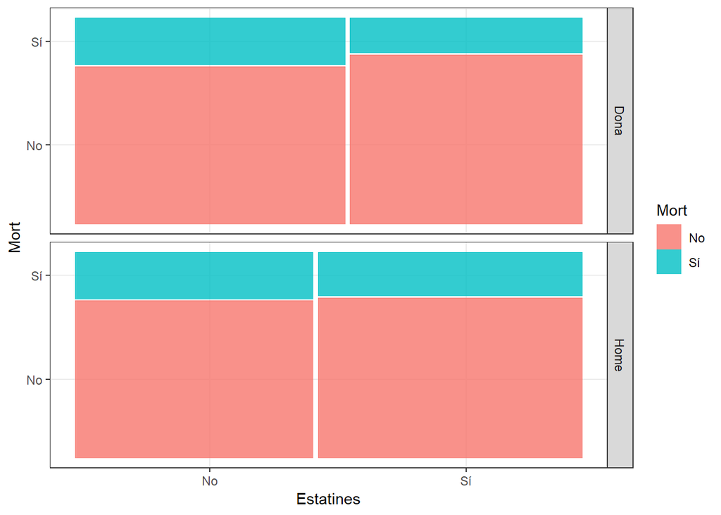

Els coeficients del model són:

```
##                         (Intercept)                                Edat
##                         -2.05050690                          0.94924088
##                            SexeHome                               HTASí
##                         -0.10422470                          0.13701062
##                      HiperlipemiaSí                          ObesitatSí
##                          0.16400407                         -0.02534268
##                            Ant.CISí                           Ant.MVPSí
##                         -0.04814814                          0.23756415
##                      Ant.Ins.CardSí                           Ant.MRCSí
##                          0.39266755                          0.18084175
##                          Ant.MReuSí                            CàncerSí
##                          0.07087449                          0.28602201
##                         EstatinesSí                            FibratSí
##                         -0.18143895                          0.60679106
##                        Omacor..1gSí                              IECASí
##                          3.29287501                         -0.27330480
##                              ARA2Sí                          InsulinaSí
##                         -0.46365375                          0.40483999
##                            ISGLT2Sí   Antiagregants.AnticoagulantsNACOs
##                         -0.71399155                          0.01407731
##      Antiagregants.AnticoagulantsNo Antiagregants.AnticoagulantsSintrom
##                         -0.26739196                         -0.20006229
##                   LDL..abans.ingrès                             FebreSí
##                         -0.06997958                          0.38654558
##                               TosSí                           DispneaSí
##                         -0.07834290                         -0.01751267
##                      RX.tòraxNormal                       Leucos.totals
##                         -0.46608735                          0.25600859
##                       Limfos.totals                           Ferritina
##                         -0.11538123                          0.18651633
##                                 PCR                             Dímer.D
##                          0.19579709                          0.10867532
##                               Sa.O2                         PaO2..mmHg.
##                         -0.25749460                          0.04724466
##                     FIO2..decimals.                                PaFi
##                          0.27609655                         -0.40135521
```

Veiem que aquí les estatines també hi són i amb un coeficient negatiu, així que confirmem que són protectores.

L’encert predictiu del model és:

```
## [1] 0.8378378
```

I la taula de contingència és:

```
##
## preds  No  Sí
##    No 171  33
##    Sí   3  15
```

Dibuixem la corba ROC:

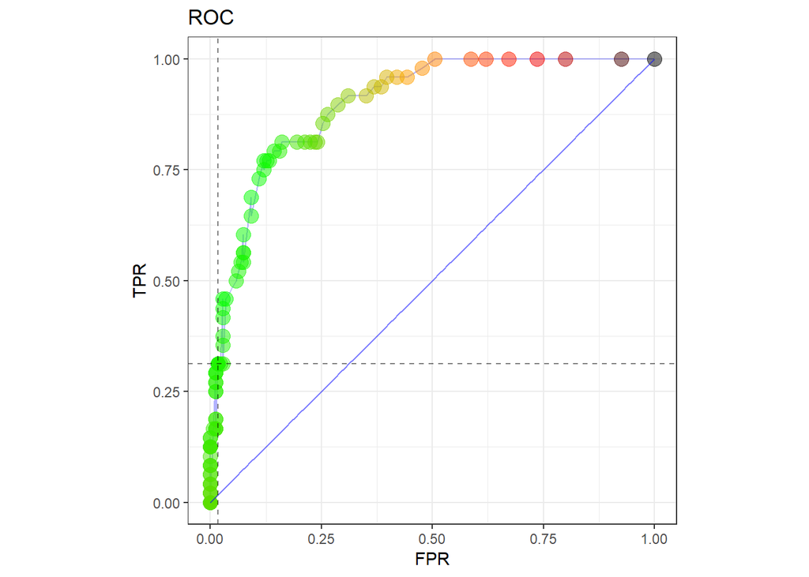

L’àrea sota la corba és:

L’àrea sota la corba és 0.8993056 and interval de confiança 0.8557958, 0.9428153.

# Models Machine learning

```
## Algorithms Trained: Random Forest, eXtreme Gradient Boosting, and glmnet
## Model Name: Mort
## Target: Mort
## Class: Classification
## Performance Metric: AUROC
## Number of Observations: 1108
## Number of Features: 106
## Models Trained: 2020-06-15 23:00:31
##
## Models tuned via 5-fold cross validation over 10 combinations of hyperparameter values.
## Best model: eXtreme Gradient Boosting
## AUPR = 0.64, AUROC = 0.88
## Optimal hyperparameter values:
##   nrounds = 430
##   max_depth = 6
##   eta = 0.012
##   gamma = 6.9
##   colsample_bytree = 0.77
##   min_child_weight = 5.8
##   subsample = 0.66
```

Fem gràfics per entendre’l millor:

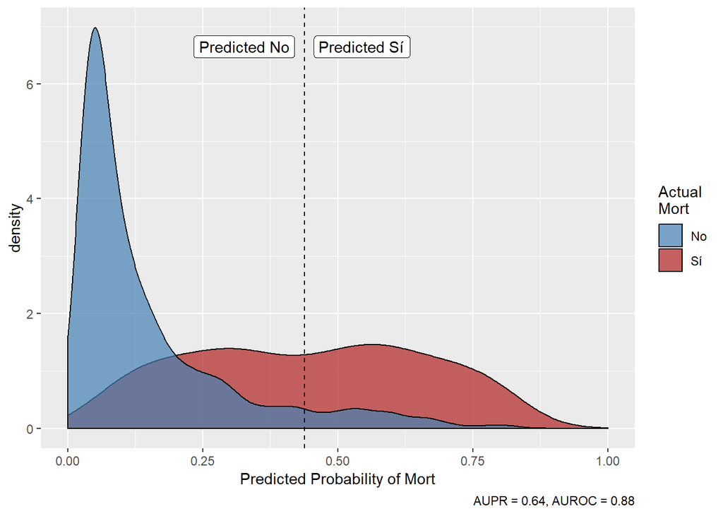

Veiem que la nostra capacitat per separar els que moriran dels que no és força bona.

La matriu de contingència és:

```
##
##       No  Sí
##   Sí 100 137
##   No  51 820
```

L’encert és 83.03%.

Fem un gràfic dels coeficients de cada variable:

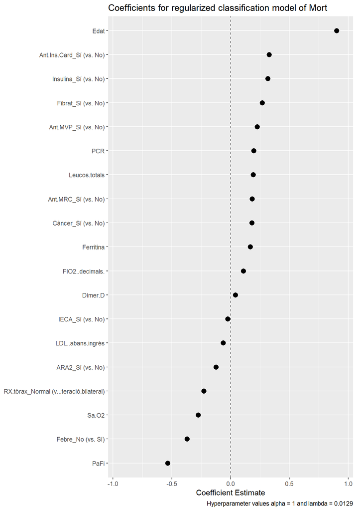

Ara mirem l’influència de cada una de les variables:

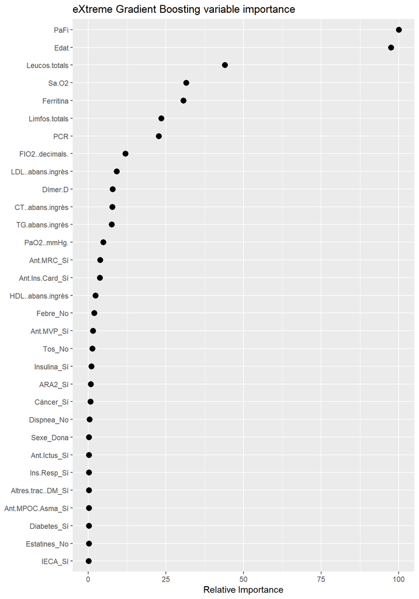

Veiem que les estatines no estan entre les més altes, però són allà.